# Week 8 Assignment - One-Way ANOVA Examples

Ryan Durfey

Monday, November 17, 2014

### Examples 7.3.1-7.3.4

```r
require(faraway)
require(mosaic)
require(fastR)
## in r-chunk, use message=FALSE to avoid outputting extra messages from require/library calls
```

```r
## Example 7.3.1
## look at and plot the data for visualization
coagulation
```

```
##    coag diet
## 1    62    A
## 2    60    A
## 3    63    A
## 4    59    A
## 5    63    B
## 6    67    B
## 7    71    B
## 8    64    B
## 9    65    B
## 10   66    B
## 11   68    C
## 12   66    C
## 13   71    C
## 14   67    C
## 15   68    C
## 16   68    C
## 17   56    D
## 18   62    D
## 19   60    D
## 20   61    D
## 21   63    D
## 22   64    D
## 23   63    D
## 24   59    D
```

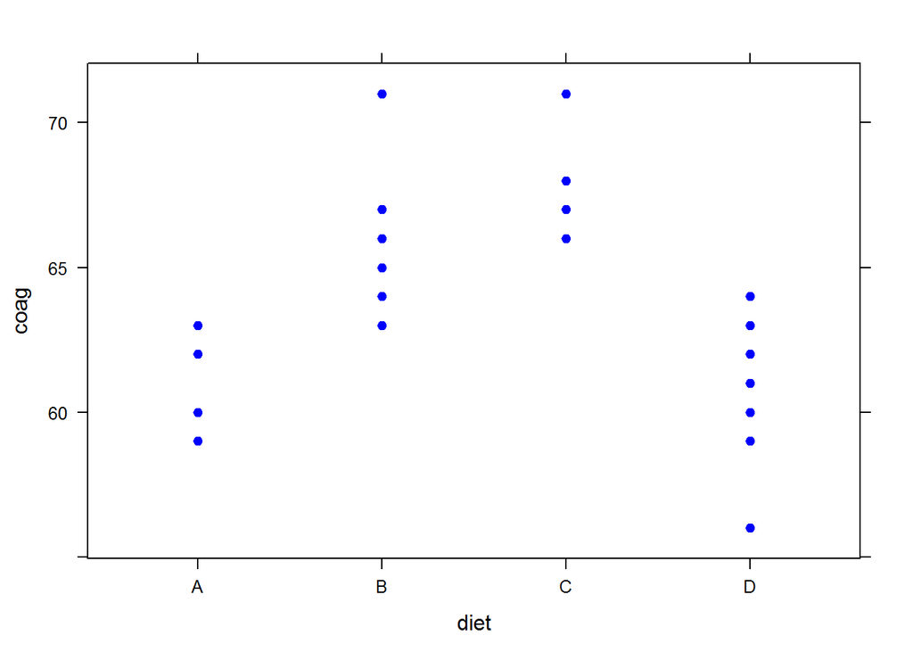

```r
xyplot(coag~diet,data=coagulation,pch=19,col="blue")
```

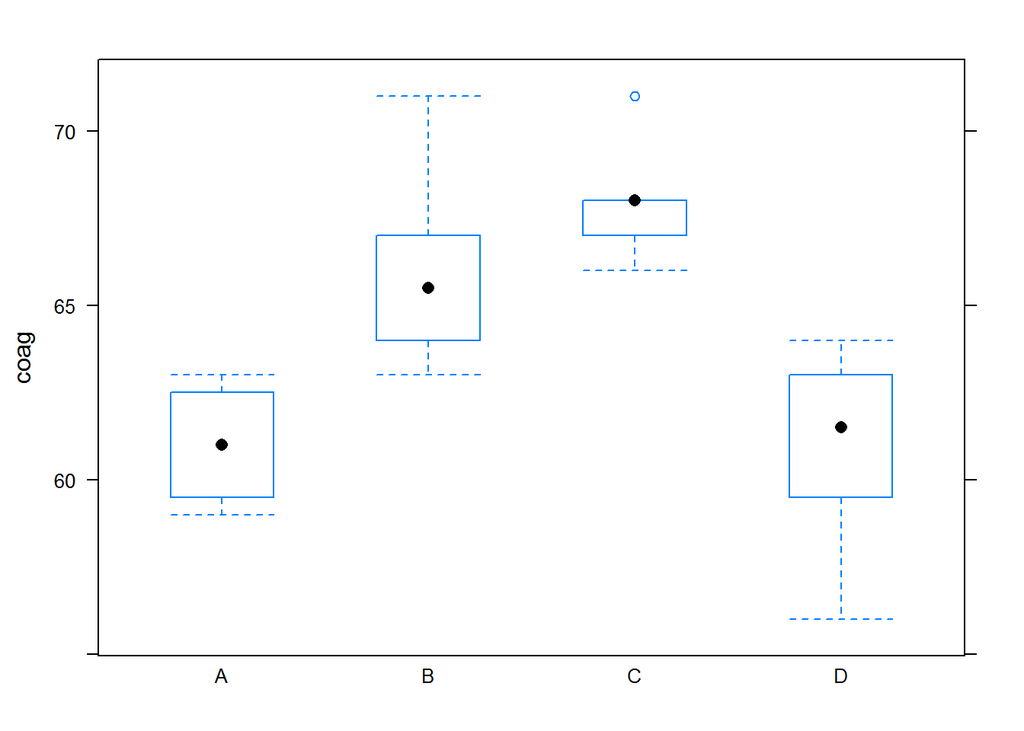

```r
bwplot(coag~diet,coagulation)
```

```r
## visually look at group means
coag.data.stats<-favstats(coag~diet,data=coagulation)
coag.data.stats
```

```
##   .group min    Q1 median    Q3 max mean    sd n missing
## 1      A  59 59.75   61.0 62.25  63   61 1.826 4       0
## 2      B  63 64.25   65.5 66.75  71   66 2.828 6       0
## 3      C  66 67.25   68.0 68.00  71   68 1.673 6       0
## 4      D  56 59.75   61.5 63.00  64   61 2.619 8       0
```

```r
coag.data.means<-cbind(mean=coag.data.stats[,7],size=coag.data.stats[,9])
coag.data.means
```

```
##      mean size
## [1,]   61    4
## [2,]   66    6
## [3,]   68    6
## [4,]   61    8
```

```r
## Example 7.3.2
## fit linear model
coag.data.model<-lm(coag~diet,data=coagulation)
summary(coag.data.model)
```

```
##
## Call:
## lm(formula = coag ~ diet, data = coagulation)
##
## Residuals:
##    Min     1Q Median     3Q    Max
##  -5.00  -1.25   0.00   1.25   5.00
##
## Coefficients:
##             Estimate Std. Error t value Pr(>|t|)
## (Intercept) 6.10e+01   1.18e+00   51.55  < 2e-16 ***
## dietB       5.00e+00   1.53e+00    3.27  0.00380 **
## dietC       7.00e+00   1.53e+00    4.58  0.00018 ***
## dietD       2.99e-15   1.45e+00    0.00  1.00000
## ---
## Signif. codes:  0 '***' 0.001 '**' 0.01 '*' 0.05 '.' 0.1 ' ' 1
##
## Residual standard error: 2.37 on 20 degrees of freedom
## Multiple R-squared:  0.671,  Adjusted R-squared:  0.621
## F-statistic: 13.6 on 3 and 20 DF,  p-value: 4.66e-05
```

```r
anova(coag.data.model)
```

```
## Analysis of Variance Table
##
## Response: coag
##           Df Sum Sq Mean Sq F value  Pr(>F)
## diet       3    228    76.0    13.6 4.7e-05 ***
## Residuals 20    112     5.6
## ---
## Signif. codes:  0 '***' 0.001 '**' 0.01 '*' 0.05 '.' 0.1 ' ' 1
```

```r
## Example 7.3.3
## create matrix of inputs for ANOVA
coag<-coagulation
coag$x1<-coag$diet=='B'
coag$x2<-coag$diet=='C'
coag$x3<-coag$diet=='D'
coag
```

```
##    coag diet    x1    x2    x3
## 1    62    A FALSE FALSE FALSE
## 2    60    A FALSE FALSE FALSE
## 3    63    A FALSE FALSE FALSE
## 4    59    A FALSE FALSE FALSE
## 5    63    B  TRUE FALSE FALSE
## 6    67    B  TRUE FALSE FALSE
## 7    71    B  TRUE FALSE FALSE
## 8    64    B  TRUE FALSE FALSE
## 9    65    B  TRUE FALSE FALSE
## 10   66    B  TRUE FALSE FALSE
## 11   68    C FALSE  TRUE FALSE
## 12   66    C FALSE  TRUE FALSE
## 13   71    C FALSE  TRUE FALSE
## 14   67    C FALSE  TRUE FALSE
## 15   68    C FALSE  TRUE FALSE
## 16   68    C FALSE  TRUE FALSE
## 17   56    D FALSE FALSE  TRUE
## 18   62    D FALSE FALSE  TRUE
## 19   60    D FALSE FALSE  TRUE
## 20   61    D FALSE FALSE  TRUE
## 21   63    D FALSE FALSE  TRUE
## 22   64    D FALSE FALSE  TRUE
## 23   63    D FALSE FALSE  TRUE
## 24   59    D FALSE FALSE  TRUE
```

#### Note:

We create three input variables instead of four, which is the number of input groups, because the first input group, ‘A’, is considered the intercept and does not have a ‘x’ variable attached to it in our model. Ultimately, we are comparing the three input variable groups to the first group to determine if they are different.

```r
## create linear models and compare them with anova
coag.model.all<-lm(coag~x1+x2+x3,data=coag)
coag.model.null<-lm(coag~1,data=coag)
anova(coag.model.null,coag.model.all)
```

```
## Analysis of Variance Table
##
## Model 1: coag ~ 1
## Model 2: coag ~ x1 + x2 + x3
##   Res.Df RSS Df Sum of Sq    F  Pr(>F)
## 1     23 340
## 2     20 112  3       228 13.6 4.7e-05 ***
## ---
## Signif. codes:  0 '***' 0.001 '**' 0.01 '*' 0.05 '.' 0.1 ' ' 1
```

```r
## compare above output with linear model and anova of original
summary(coag.data.model)
```

```
##
## Call:
## lm(formula = coag ~ diet, data = coagulation)
##
## Residuals:
##    Min     1Q Median     3Q    Max
##  -5.00  -1.25   0.00   1.25   5.00
##
## Coefficients:
##             Estimate Std. Error t value Pr(>|t|)
## (Intercept) 6.10e+01   1.18e+00   51.55  < 2e-16 ***
## dietB       5.00e+00   1.53e+00    3.27  0.00380 **
## dietC       7.00e+00   1.53e+00    4.58  0.00018 ***
## dietD       2.99e-15   1.45e+00    0.00  1.00000
## ---
## Signif. codes:  0 '***' 0.001 '**' 0.01 '*' 0.05 '.' 0.1 ' ' 1
##
## Residual standard error: 2.37 on 20 degrees of freedom
## Multiple R-squared:  0.671,  Adjusted R-squared:  0.621
## F-statistic: 13.6 on 3 and 20 DF,  p-value: 4.66e-05
```

```r
anova(coag.data.model)
```

```
## Analysis of Variance Table
##
## Response: coag
##           Df Sum Sq Mean Sq F value  Pr(>F)
## diet       3    228    76.0    13.6 4.7e-05 ***
## Residuals 20    112     5.6
## ---
## Signif. codes:  0 '***' 0.001 '**' 0.01 '*' 0.05 '.' 0.1 ' ' 1
```

```r
## Example 7.3.4
## means for calculation sum of squares
grand.mean<-mean(coagulation$coag)
grand.mean
```

```
## [1] 64
```

```r
create.vector.means<-function(my.group.data){
        rep(my.group.data[1],my.group.data[2])
}
group.mean<-unlist(apply(coag.data.means,1,create.vector.means))
group.mean
```

```
## mean mean mean mean mean mean mean mean mean mean mean mean mean mean mean
##   61   61   61   61   66   66   66   66   66   66   68   68   68   68   68
## mean mean mean mean mean mean mean mean mean
##   68   61   61   61   61   61   61   61   61
```

```r
## Explanation of the method for group means (further explanation for what was just done above)
coag.data.means
```

```
##      mean size
## [1,]   61    4
## [2,]   66    6
## [3,]   68    6
## [4,]   61    8
```

```r
## apply creates the list of vectors, with each vector being the group mean repeated as many times as the group element appears (e.g., how many times 'B' appears)
apply(coag.data.means,1,create.vector.means)
```

```
## [[1]]
## mean mean mean mean
##   61   61   61   61
##
## [[2]]
## mean mean mean mean mean mean
##   66   66   66   66   66   66
##
## [[3]]
## mean mean mean mean mean mean
##   68   68   68   68   68   68
##
## [[4]]
## mean mean mean mean mean mean mean mean
##   61   61   61   61   61   61   61   61
```

```r
## unlist is the function that can concatenate elements in a list into a single vector
unlist(apply(coag.data.means,1,create.vector.means))
```

```
## mean mean mean mean mean mean mean mean mean mean mean mean mean mean mean
##   61   61   61   61   66   66   66   66   66   66   68   68   68   68   68
## mean mean mean mean mean mean mean mean mean
##   68   61   61   61   61   61   61   61   61
```

```r
## calculation of SST, SSE, and SSM
SST<-sum((coagulation$coag-grand.mean)^2)
SSE<-sum((coagulation$coag-group.mean)^2)
SSM<-sum((group.mean-grand.mean)^2)
SST
```

```
## [1] 340
```

```r
SSE
```

```
## [1] 112
```

```r
SSM
```

```
## [1] 228
```

```r
## note that SST=SSE+SSM
SST==SSE+SSM
```

```
## [1] TRUE
```

```r
## compare these calculated values with original linear model
summary(coag.data.model)
```

```
##
## Call:
## lm(formula = coag ~ diet, data = coagulation)
##
## Residuals:
##    Min     1Q Median     3Q    Max
##  -5.00  -1.25   0.00   1.25   5.00
##
## Coefficients:
##             Estimate Std. Error t value Pr(>|t|)
## (Intercept) 6.10e+01   1.18e+00   51.55  < 2e-16 ***
## dietB       5.00e+00   1.53e+00    3.27  0.00380 **
## dietC       7.00e+00   1.53e+00    4.58  0.00018 ***
## dietD       2.99e-15   1.45e+00    0.00  1.00000
## ---
## Signif. codes:  0 '***' 0.001 '**' 0.01 '*' 0.05 '.' 0.1 ' ' 1
##
## Residual standard error: 2.37 on 20 degrees of freedom
## Multiple R-squared:  0.671,  Adjusted R-squared:  0.621
## F-statistic: 13.6 on 3 and 20 DF,  p-value: 4.66e-05
```

```r
anova(coag.data.model)
```

```
## Analysis of Variance Table
##
## Response: coag
##           Df Sum Sq Mean Sq F value  Pr(>F)
## diet       3    228    76.0    13.6 4.7e-05 ***
## Residuals 20    112     5.6
## ---
## Signif. codes:  0 '***' 0.001 '**' 0.01 '*' 0.05 '.' 0.1 ' ' 1
```

```r
## looking at what basis R uses in lm call
model.matrix(coag.data.model)
```

```
##    (Intercept) dietB dietC dietD
## 1            1     0     0     0
## 2            1     0     0     0
## 3            1     0     0     0
## 4            1     0     0     0
## 5            1     1     0     0
## 6            1     1     0     0
## 7            1     1     0     0
## 8            1     1     0     0
## 9            1     1     0     0
## 10           1     1     0     0
## 11           1     0     1     0
## 12           1     0     1     0
## 13           1     0     1     0
## 14           1     0     1     0
## 15           1     0     1     0
## 16           1     0     1     0
## 17           1     0     0     1
## 18           1     0     0     1
## 19           1     0     0     1
## 20           1     0     0     1
## 21           1     0     0     1
## 22           1     0     0     1
## 23           1     0     0     1
## 24           1     0     0     1
## attr(,"assign")
## [1] 0 1 1 1
## attr(,"contrasts")
## attr(,"contrasts")$diet
## [1] "contr.treatment"
```

```r
## now for a model without the intercept
coag.data.altmodel<-lm(coag~diet-1,data=coagulation)
summary(coag.data.altmodel)
```

```
##
## Call:
## lm(formula = coag ~ diet - 1, data = coagulation)
##
## Residuals:
##    Min     1Q Median     3Q    Max
##  -5.00  -1.25   0.00   1.25   5.00
##
## Coefficients:
##       Estimate Std. Error t value Pr(>|t|)
## dietA   61.000      1.183    51.5   <2e-16 ***
## dietB   66.000      0.966    68.3   <2e-16 ***
## dietC   68.000      0.966    70.4   <2e-16 ***
## dietD   61.000      0.837    72.9   <2e-16 ***
## ---
## Signif. codes:  0 '***' 0.001 '**' 0.01 '*' 0.05 '.' 0.1 ' ' 1
##
## Residual standard error: 2.37 on 20 degrees of freedom
## Multiple R-squared:  0.999,  Adjusted R-squared:  0.999
## F-statistic: 4.4e+03 on 4 and 20 DF,  p-value: <2e-16
```

```r
anova(coag.data.altmodel)
```

```
## Analysis of Variance Table
##
## Response: coag
##           Df Sum Sq Mean Sq F value Pr(>F)
## diet       4  98532   24633    4399 <2e-16 ***
## Residuals 20    112       6
## ---
## Signif. codes:  0 '***' 0.001 '**' 0.01 '*' 0.05 '.' 0.1 ' ' 1
```

```r
## compare with the anova for original model
anova(coag.data.model)
```

```
## Analysis of Variance Table
##
## Response: coag
##           Df Sum Sq Mean Sq F value  Pr(>F)
## diet       3    228    76.0    13.6 4.7e-05 ***
## Residuals 20    112     5.6
## ---
## Signif. codes:  0 '***' 0.001 '**' 0.01 '*' 0.05 '.' 0.1 ' ' 1
```

#### Comparing ANOVA tables:

Comparing ANOVA tables for the original model (coag.data.model) and the alternative one without the intercept (coag.data.altmodel), the F-values are much different. The F-value for the alternative model is 4399, which is much larger than that of the original model’s F-value of 13.6. However, this is due to the fact that each is testing different null hypotheses, as is highlighted below.

```r
## look at the basis for the alternative model
model.matrix(coag.data.altmodel)
```

```
##    dietA dietB dietC dietD
## 1      1     0     0     0
## 2      1     0     0     0
## 3      1     0     0     0
## 4      1     0     0     0
## 5      0     1     0     0
## 6      0     1     0     0
## 7      0     1     0     0
## 8      0     1     0     0
## 9      0     1     0     0
## 10     0     1     0     0
## 11     0     0     1     0
## 12     0     0     1     0
## 13     0     0     1     0
## 14     0     0     1     0
## 15     0     0     1     0
## 16     0     0     1     0
## 17     0     0     0     1
## 18     0     0     0     1
## 19     0     0     0     1
## 20     0     0     0     1
## 21     0     0     0     1
## 22     0     0     0     1
## 23     0     0     0     1
## 24     0     0     0     1
## attr(,"assign")
## [1] 1 1 1 1
## attr(,"contrasts")
## attr(,"contrasts")$diet
## [1] "contr.treatment"
```

#### Differences between the bases:

The basis created using the original model’s basis has a column entirely made of 1’s (the 1 vector), whereas the basis from the alternative model does not. The original model’s base is not orthogonal, but the alternative’s basis is.

#### Null Hypotheses from both models:

The null hypotheses for each model are actually quite different from one another.

The original model’s null hypothesis is: H0: mu-1 = mu-2 = mu-3 = mu-4

The alternative model’s null hypothesis is: H0: mu-1 = mu-2 = mu-3 = mu-4 = 0

Note that the alternative model’s null hypothesis has every group mean equal to zero. This is because it is treated like a variable instead of an intercept. Thus, what the alternative model is testing if group means are equal to zero whereas the original model is testing if the means are different than the intercept (which in this case is the mean of the first group).

This difference in null hypotheses has a big impact on the interpretation of our results. For instance, the extremely large F-value seen with the alternative model makes sense now, because all the group means are definitely not zero and the null is easily rejected. Alternatively, with the original model, it is not quite as outlandish to suggest that the group means are equal. However, the original model’s F-value here is still high enough to produce a p-value to reject its null hypothesis, but we are simply noting that it is just not as extreme as in the alternative model’s case.

### Example 7.3.5

```r
## vizualize the data
airpollution
```

```
##   pollution      location
## 1       124   Hill Suburb
## 2       110   Hill Suburb
## 3       107 Plains Suburb
## 4       115 Plains Suburb
## 5       126    Urban City
## 6       138    Urban City
```

```r
## calculate group means
mean(pollution~location,data=airpollution)
```

```
##   Hill Suburb Plains Suburb    Urban City
##           117           111           132
```

```r
## fit linear model and run anova
airpoll.model<-lm(pollution~location,data=airpollution)
anova(airpoll.model)
```

```
## Analysis of Variance Table
##
## Response: pollution
##           Df Sum Sq Mean Sq F value Pr(>F)
## location   2    468   234.0    3.48   0.17
## Residuals  3    202    67.3
```